# 数据可视化

## 常用图形

- 曲线图：`matplotlib.pyplot.plot(data)`
- 灰度图：`matplotlib.pyplot.hist(data)`
- 散点图：`matplotlib.pyplot.scatter(data)`
- 箱式图：`matplotlib.pyplot.boxplot(data)`

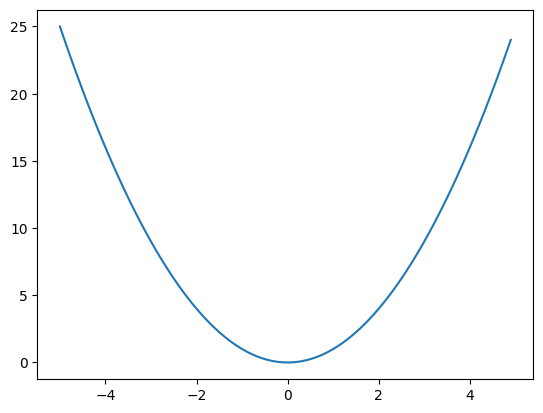

```python
x = np.arange(-5,5,0.1) # -5到5区间，相隔0.1取点为list
y = x ** 2
plt.plot(x,y)
# 曲线图演示
```

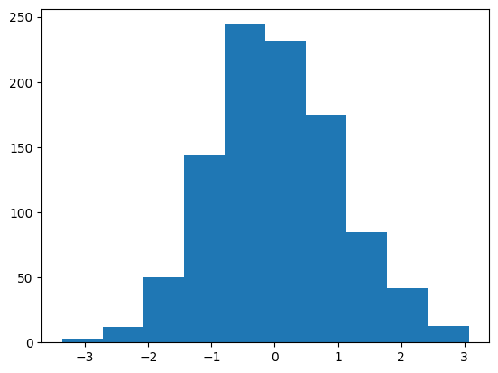

```python
x = np.random.normal(size=1000) # 随机生成正态分布的1000个样本
plt.hist(x, bins=10)
# 灰度图histogram，其中bins是柱子的数目
```

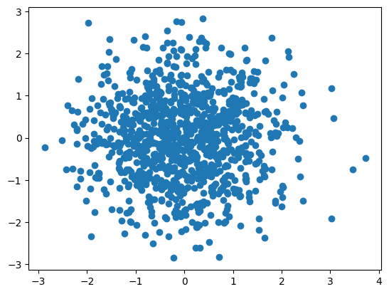

```python
x = np.random.normal(size=1000)
y = np.random.normal(size=1000)
plt.scatter(x,y)
# 散点图
```

[output not shown]

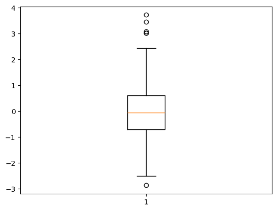

```python
plt.boxplot(x)
# 箱式图  （正态分布）
```

#### 箱式图科普

[figure not shown]

（信息含量很大～有一半的数值都在箱子里面）

- 上边缘（Q3+1.5IQR）、下边缘（Q1-1.5IQR）（其中 **IQR=Q3-Q1** 是 interquartile range）

  （虚线延伸到两边的黑色线）
- 上四分位数（Q3）、下四分位数（Q1）（箱子左右蓝色的边框）：排序后第25%和第75%处的样本数值
- 中位数（箱子中间的红色线）：排序后第50%处的样本数值，不受异常值影响！

  <注：均值是所有数据的平均值，受异常值影响！>
- 异常值（上下边缘以外的点被定义为异常值，算是异常值的阈值）
  - 处理异常值时与3σ标准的异同：统计边界是否受异常值影响、容忍度的大小
  - FYI：$\sigma \Rightarrow 68.2\%$，$2\sigma \Rightarrow 95.4\%$，$3\sigma \Rightarrow 99.7\%$
- 3σ 标准以均值和方差作为度量，异常值对其的影响是非常大的。若按照分位数刻画的箱式图来考察的话，只要异常值不影响排序，那么异常值的大小是怎样都是什么关系的，但对于3σ标准来说，不管异常值是否影响排序，其值的任何变化都会显著影响方差σ。
- 所以，如果能估计出数据存在特别特别离谱的异常值时，建议可以通过箱式图来考察，去度量数据的统计特性、集中程度、分布情况等；若数据中没有太可能有太多异常值的时候，就可以用3σ标准来考察。
- 例子：
  - 箱子很短，说明数据很集中；箱子很长，说明数据很分散；虚线很长，说明异常值不仅大，还非常多。所以，如果想截取一个干净的数据，就需要把分位数的上下阈值定的足够的窄才行。

## 常用样式

[figure not shown]

### 颜色/线型/标记

- `pyplot.plot(x, color='g')` 颜色
- `pyplot.plot(x, linestyle='—')` 线形
- `pyplot.plot(x, marker='+')` 曲线上的点
- `pyplot.plot(x, 'ro-')`

### 标题

- `pyplot.title("xxxx")`

### 坐标轴标签

- `pyplot.xlabel("xxxx")`
- `pyplot.ylabel("xxxx")`

### 图注

- `pyplot.legend(loc="best")` 配合 `pyplot.plot(label="xxxx")`

### 网格

- `pyplot.grid(color="xxx", linestyle="-", alpha=0.5)`

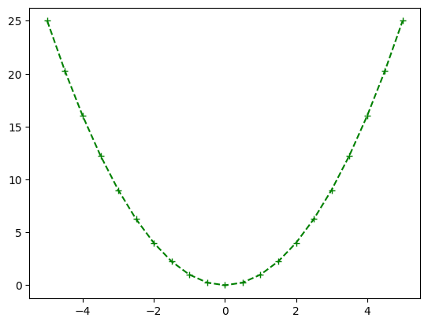

```python
x = np.arange(-5,5.5,0.5)
y = x ** 2
plt.plot(x,y,color='g',linestyle='--',marker='+')
# 颜色/线型/标记
```

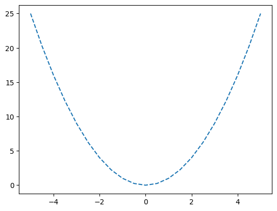

```python
plt.plot(x,y,linestyle='--')
```

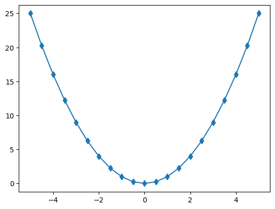

```python
plt.plot(x,y,marker='d')
```

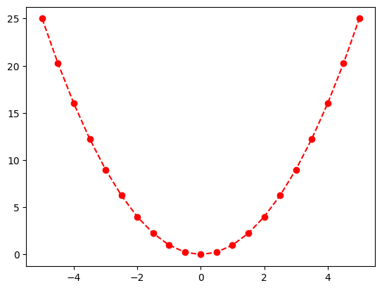

```python
plt.plot(x,y,'ro--') # 可以合在一起写
```

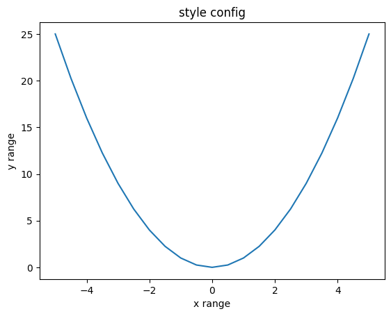

```python
plt.plot(x,y)
plt.title("style config")   # 标题
plt.xlabel("x range")       # 横坐标
plt.ylabel("y range")       # 纵坐标
```

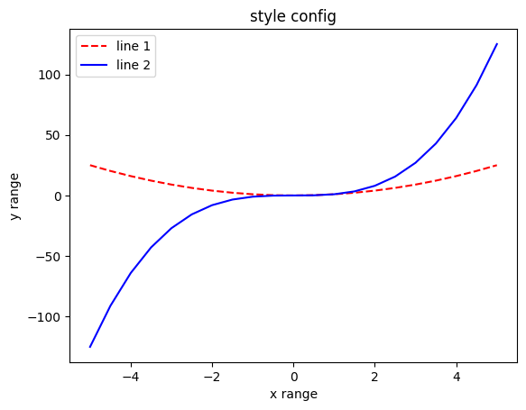

```python
y1 = x ** 2
y2 = x ** 3
plt.plot(x,y1,'r--',label='line 1')
plt.plot(x,y2,'b-',label='line 2')
plt.title("style config")
plt.xlabel("x range")
plt.ylabel("y range")
plt.legend(loc="best")
```

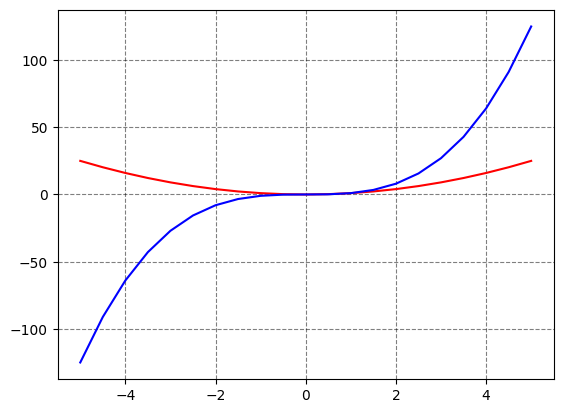

```python
plt.plot(x,y1,'r')
plt.plot(x,y2,'b')
plt.grid(color='k',linestyle='--',alpha=0.5)   # 设置网格 alpha参数表示透明度(%)
```

# 华盛顿自行车租赁情况分析案例(Matplotlib)

## 实验准备

> 5 min

### 实验背景

matplotlib是基于numpy的一套Python工具包。这个包提供了丰富的数据绘图工具，主要用于绘制一些统计图形。

通过本次实验我们对 Matplotlib 在数据可视化的具体应用进行进一步理解与解读。

### 实验步骤

本次实验分为以下几个环节：

- 1. 确认数据
- 2. 配置参数
- 3. 关联分析
- 4. 分布分析
- 5. 组间分析
- 6. 小结

## 2. 实验操作

> 60 min

### 步骤1：确认数据

首先，引入案例所需的python库，本案例需要的库有：

- pandas ： 读取数据到DataFrame
- urllib ： 获取网络数据
- tempfile : 创建临时文件系统
- shutil : 文件操作
- zipfile : 压缩解压

```python
import pandas as pd  # 读取数据到DataFrame
import urllib    # 获取网络数据
import tempfile  # 创建临时文件系统
import shutil    # 文件操作
import zipfile   # 压缩解压
```

然后，建立一个临时目录，下载案例所需的数据文件，并解压。

```python
temp_dir = tempfile.mkdtemp() # 建立临时目录
data_source = 'http://archive.ics.uci.edu/ml/machine-learning-databases/00275/Bike-Sharing-Dataset.zip' # 网络数据地址
zipname = temp_dir + '/Bike-Sharing-Dataset.zip' # 拼接文件和路径

try:
    urllib.urlretrieve(data_source, zipname) # 获得数据 python2.x
except:
    urllib.request.urlretrieve(data_source, zipname) # 获得数据  python3.x

zip_ref = zipfile.ZipFile(zipname, 'r') # 创建一个ZipFile对象处理压缩文件
zip_ref.extractall(temp_dir) # 解压
zip_ref.close()
```

使用pandas读取解压后的csv文件：

```python
daily_path = temp_dir + '/day.csv'
daily_data = pd.read_csv(daily_path) # 读取csv文件
```

对数据进行一些初步处理：

- 字符串转换成日期数据
- 去掉不关注的列

```python
daily_data['dteday'] = pd.to_datetime(daily_data['dteday'])  # 把字符串数据传换成日期数据
drop_list = ['instant', 'season', 'yr', 'mnth', 'holiday', 'workingday', 'weathersit', 'atemp', 'hum'] # 不关注的列
daily_data.drop(drop_list, inplace = True, axis = 1) # inplace=true在对象上直接操作
shutil.rmtree(temp_dir) # 删除临时文件目录
```

看一看处理后的数据：

```python
# 查看数据
daily_data.head()
```

|  | dteday | weekday | temp | windspeed | casual | registered | cnt |
| --- | --- | --- | --- | --- | --- | --- | --- |
| 0 | 2011-01-01 | 6 | 0.344167 | 0.160446 | 331 | 654 | 985 |
| 1 | 2011-01-02 | 0 | 0.363478 | 0.248539 | 131 | 670 | 801 |
| 2 | 2011-01-03 | 1 | 0.196364 | 0.248309 | 120 | 1229 | 1349 |
| 3 | 2011-01-04 | 2 | 0.200000 | 0.160296 | 108 | 1454 | 1562 |
| 4 | 2011-01-05 | 3 | 0.226957 | 0.186900 | 82 | 1518 | 1600 |

```python
daily_data.info()
```

```
<class 'pandas.core.frame.DataFrame'>
RangeIndex: 731 entries, 0 to 730
Data columns (total 7 columns):
 #   Column      Non-Null Count  Dtype
---  ------      --------------  -----
 0   dteday      731 non-null    datetime64[ns]
 1   weekday     731 non-null    int64
 2   temp        731 non-null    float64
 3   windspeed   731 non-null    float64
 4   casual      731 non-null    int64
 5   registered  731 non-null    int64
 6   cnt         731 non-null    int64
dtypes: datetime64[ns](1), float64(2), int64(4)
memory usage: 40.1 KB
```

数据来源：https://www.kaggle.com/c/bike-sharing-demand/data

### 步骤2：配置参数

引入 matplotlib 包：

```python
# 引入3.x版本的除法和打印
from __future__ import division, print_function
from matplotlib import pyplot as plt
import pandas as pd
import numpy as np
# 在notebook中显示绘图结果
%matplotlib inline
```

设置一些全局的资源参数，可以进行个性化修改：

- 设置图片尺寸 8" x 4"

```python
import matplotlib
# rc: resource configuration
matplotlib.rc('figure', figsize = (8, 4))
```

```python
matplotlib.rc('font', size = 12)
```

- 设置不显示网格

```python
matplotlib.rc('axes', grid = False)
```

- 设置背景颜色是白色

```python
matplotlib.rc('axes', facecolor = 'white')
```

```python
# matplotlib.rcParams
```

### 步骤3：关联分析

关联分析是所有分析中的第一步！考虑的两组数据之间是否存在关系～

#### 散点图

- 分析变量关系

  判断：“正相关”？“负相关”？还是“不相关”？

```python
# 查看数据
daily_data.head()
```

|  | dteday | weekday | temp | windspeed | casual | registered | cnt |
| --- | --- | --- | --- | --- | --- | --- | --- |
| 0 | 2011-01-01 | 6 | 0.344167 | 0.160446 | 331 | 654 | 985 |
| 1 | 2011-01-02 | 0 | 0.363478 | 0.248539 | 131 | 670 | 801 |
| 2 | 2011-01-03 | 1 | 0.196364 | 0.248309 | 120 | 1229 | 1349 |
| 3 | 2011-01-04 | 2 | 0.200000 | 0.160296 | 108 | 1454 | 1562 |
| 4 | 2011-01-05 | 3 | 0.226957 | 0.186900 | 82 | 1518 | 1600 |

```python
# 包装一个散点图的函数便于复用
def scatterplot(x_data, y_data, x_label, y_label, title, ax = None):

    # 创建一个绘图对象
    if ax:
        pass
    else:
        fig, ax = plt.subplots()
    # 调用plt句柄画一个图，返回两个变量fig，ax，分别是figure和 axes的缩写。函数返回一个figure图像和一个子图ax的array列表。
    # 一个fig图里边会套好几个ax，而每个ax会负责当前坐标上的图。所以任何绘制的图形都是在ax上完成的；
    # 而设置整个画布，将是在fig上完成。

    # 不显示顶部和右侧的坐标线
    ax.spines['top'].set_color('none')
    ax.spines['right'].set_color('none')
    # 设置数据x_data和y_data、点的大小s、点的颜色color和透明度alpha
    ax.scatter(x_data, y_data, s = 10, color = '#539caf', alpha = 0.75)

    # 添加标题和坐标说明
    ax.set_title(title)
    ax.set_xlabel(x_label)
    ax.set_ylabel(y_label)
```

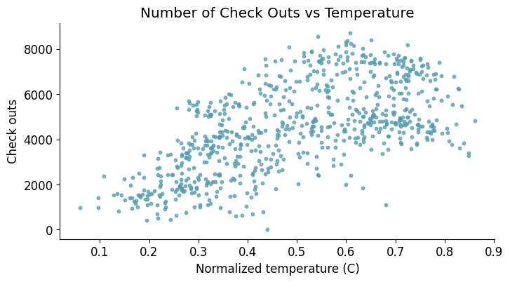

```python
# 绘制散点图
scatterplot(x_data = daily_data['temp']
            , y_data = daily_data['cnt']
            , x_label = 'Normalized temperature (C)'
            , y_label = 'Check outs'
            , title = 'Number of Check Outs vs Temperature')
```

#### 曲线图

拟合变量关系（绘制拟合关联曲线）

```python
# 线性回归
# !pip install statsmodels
import statsmodels.api as sm
from statsmodels.stats.outliers_influence import summary_table
x = sm.add_constant(daily_data['temp']) # 线性回归增加常数项
y = daily_data['cnt']
regr = sm.OLS(y, x) # 普通最小二乘模型，ordinary least square model
res = regr.fit()

# 从模型获得拟合数据
st, data, ss2 = summary_table(res, alpha=0.05) # 置信水平alpha=5%，st数据汇总，data数据详情，ss2数据列名
fitted_values = data[:,2]
```

```python
# x.head()
# type(regr)  # 普通最小二乘模型
# st          # 数据汇总
```

包装曲线绘制函数

```python
def lineplot(x_data, y_data, x_label, y_label, title):
    # 创建绘图对象
    _, ax = plt.subplots()

    # 绘制拟合曲线，lw=linewidth，alpha=transparancy
    ax.plot(x_data, y_data, lw = 2, color = '#539caf', alpha = 1)

    # 添加标题和坐标说明
    ax.set_title(title)
    ax.set_xlabel(x_label)
    ax.set_ylabel(y_label)
```

调用绘图函数

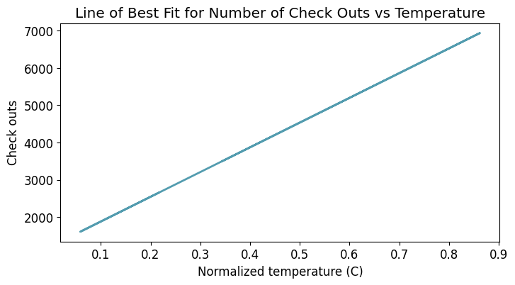

```python
lineplot(x_data = daily_data['temp']
         , y_data = fitted_values
         , x_label = 'Normalized temperature (C)'
         , y_label = 'Check outs'
         , title = 'Line of Best Fit for Number of Check Outs vs Temperature')
```

#### 带置信区间的曲线图

评估曲线拟合结果（对曲线图的进一步分析～）

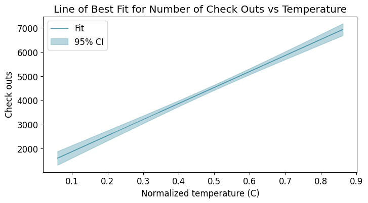

```python
# 获得5%置信区间的上下界
predict_mean_ci_low, predict_mean_ci_upp = data[:,4:6].T

# 创建置信区间DataFrame，上下界
CI_df = pd.DataFrame(columns = ['x_data', 'low_CI', 'upper_CI'])
CI_df['x_data'] = daily_data['temp']
CI_df['low_CI'] = predict_mean_ci_low
CI_df['upper_CI'] = predict_mean_ci_upp
CI_df.sort_values('x_data', inplace = True) # 根据x_data进行排序

# 绘制置信区间
def lineplotCI(x_data, y_data, sorted_x, low_CI, upper_CI, x_label, y_label, title):
    # 创建绘图对象
    _, ax = plt.subplots()

    # 绘制预测曲线
    ax.plot(x_data, y_data, lw = 1, color = '#539caf', alpha = 1, label = 'Fit')
    # 绘制置信区间，顺序填充
    ax.fill_between(sorted_x, low_CI, upper_CI, color = '#539caf', alpha = 0.4, label = '95% CI')
    # 添加标题和坐标说明
    ax.set_title(title)
    ax.set_xlabel(x_label)
    ax.set_ylabel(y_label)

    # 显示图例，配合label参数，loc=“best”自适应方式
    ax.legend(loc = 'best')
    return ax

# Call the function to create plot
ax = lineplotCI(x_data = daily_data['temp']
           , y_data = fitted_values
           , sorted_x = CI_df['x_data']
           , low_CI = CI_df['low_CI']
           , upper_CI = CI_df['upper_CI']
           , x_label = 'Normalized temperature (C)'
           , y_label = 'Check outs'
           , title = 'Line of Best Fit for Number of Check Outs vs Temperature')
```

叠加上绘制散点图

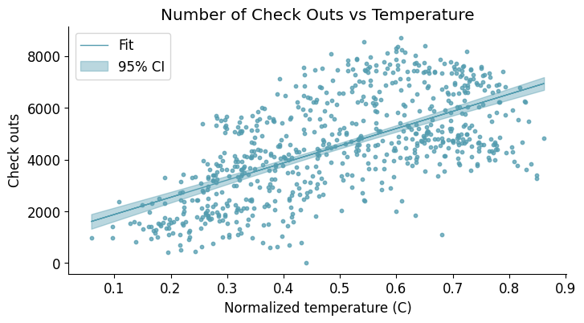

```python
ax = lineplotCI(x_data = daily_data['temp']
           , y_data = fitted_values
           , sorted_x = CI_df['x_data']
           , low_CI = CI_df['low_CI']
           , upper_CI = CI_df['upper_CI']
           , x_label = 'Normalized temperature (C)'
           , y_label = 'Check outs'
           , title = 'Line of Best Fit for Number of Check Outs vs Temperature')

scatterplot(x_data = daily_data['temp']
             , y_data = daily_data['cnt']
             , x_label = 'Normalized temperature (C)'
             , y_label = 'Check outs'
             , title = 'Number of Check Outs vs Temperature'
             , ax=ax)
```

#### 双坐标曲线图

- 曲线拟合不满足置信阈值时，考虑增加独立变量
- 分析不同尺度多变量的关系

定义双纵坐标绘图函数

```python
daily_data.head()
```

|  | dteday | weekday | temp | windspeed | casual | registered | cnt |
| --- | --- | --- | --- | --- | --- | --- | --- |
| 0 | 2011-01-01 | 6 | 0.344167 | 0.160446 | 331 | 654 | 985 |
| 1 | 2011-01-02 | 0 | 0.363478 | 0.248539 | 131 | 670 | 801 |
| 2 | 2011-01-03 | 1 | 0.196364 | 0.248309 | 120 | 1229 | 1349 |
| 3 | 2011-01-04 | 2 | 0.200000 | 0.160296 | 108 | 1454 | 1562 |
| 4 | 2011-01-05 | 3 | 0.226957 | 0.186900 | 82 | 1518 | 1600 |

```python
def lineplot2y(x_data, x_label,
               y1_data, y1_color, y1_label,
               y2_data, y2_color, y2_label, title):
    _, ax1 = plt.subplots()
    ax1.plot(x_data, y1_data, color = y1_color)
    # 添加标题和坐标说明
    ax1.set_ylabel(y1_label, color = y1_color)
    ax1.set_xlabel(x_label)
    ax1.set_title(title)

    ax2 = ax1.twinx() # 两个绘图对象共享横坐标轴（关键！）
    ax2.plot(x_data, y2_data, color = y2_color)
    ax2.set_ylabel(y2_label, color = y2_color)
    # 右侧坐标轴可见
    ax2.spines['right'].set_visible(True)
```

调用绘图函数

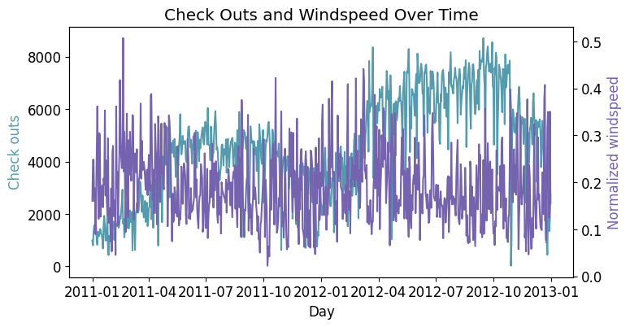

```python
lineplot2y(x_data = daily_data['dteday']
           , x_label = 'Day'
           , y1_data = daily_data['cnt']
           , y1_color = '#539caf'
           , y1_label = 'Check outs'
           , y2_data = daily_data['windspeed']
           , y2_color = '#7663b0'
           , y2_label = 'Normalized windspeed'
           , title = 'Check Outs and Windspeed Over Time')
```

从图中可以察觉到总租车量与风速的大小存在负相关性。

### 步骤4：分布分析

上一步是知道了变量之间的关系，接下来需要进一步知晓变量服从什么样的分布。因为分布情况会决定我们后续的处理方式。

#### 灰度图（粗略）

- 粗略区间计数

定义绘制灰度图的函数

```python
def histogram(data, x_label, y_label, title, bins=10):
    _, ax = plt.subplots()
    res = ax.hist(data, color = '#539caf', bins=bins) # 设置bin的数量
    ax.set_ylabel(y_label)
    ax.set_xlabel(x_label)
    ax.set_title(title)
    return res
```

调用绘图函数

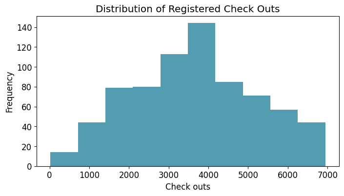

```python
res = histogram(data = daily_data['registered'],
                x_label = 'Check outs',
                y_label = 'Frequency',
                title = 'Distribution of Registered Check Outs',)
```

```python
res[0] # value of bins
```

```
array([ 14.,  44.,  79.,  80., 113., 144.,  85.,  71.,  57.,  44.])
```

```python
res[1] # boundary of bins
```

```
array([  20. ,  712.6, 1405.2, 2097.8, 2790.4, 3483. , 4175.6, 4868.2,
       5560.8, 6253.4, 6946. ])
```

可以猜一下大概的分布，比如上面的图可能是正态分布。

#### 堆叠直方图（粗略）

- 比较两个分布

定义绘制堆叠的直方图函数

```python
def overlaid_histogram(data1, data1_name, data1_color,
                       data2, data2_name, data2_color,
                       x_label, y_label, title):
    # 归一化数据区间，对齐两个直方图的bins
    max_nbins = 10
    data_range = [min(min(data1), min(data2)), max(max(data1), max(data2))]
    binwidth = (data_range[1] - data_range[0]) / max_nbins
    bins = np.arange(data_range[0], data_range[1] + binwidth, binwidth) # 生成直方图bins区间

    # Create the plot
    _, ax = plt.subplots()
    ax.hist(data1, bins = bins, color = data1_color, alpha = 1, label = data1_name)
    ax.hist(data2, bins = bins, color = data2_color, alpha = 0.75, label = data2_name)
    ax.set_ylabel(y_label)
    ax.set_xlabel(x_label)
    ax.set_title(title)
    ax.legend(loc = 'best')
```

调用绘图函数

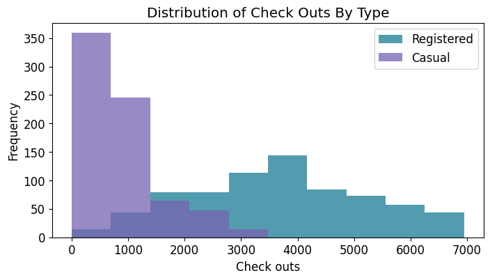

```python
overlaid_histogram(data1 = daily_data['registered'],
                   data1_name = 'Registered',
                   data1_color = '#539caf',
                   data2 = daily_data['casual'],
                   data2_name = 'Casual',
                   data2_color = '#7663b0',
                   x_label = 'Check outs',
                   y_label = 'Frequency',
                   title = 'Distribution of Check Outs By Type')
```

- 关于上图：
  - registered：注册预约过的人的分布（绿色），正态分布，why
    - 预约租车的人都是有计划性的，一般都是正态分布，呈现出大部分人在某区间内选择的现象。
  - casual：偶然来租车的人的分布（紫色），疑似指数分布，why
    - 偶然来租车的人是有随机性的～（我个人觉得可以看作是半个正态分布，表示大部分偶然租车的人，是倾向于选择少租 ）

不过总感觉灰度图太糙了，有没有~肿么破~

#### 密度图（精细）

- 精细刻画概率分布

KDE: kernal density estimate 核密度估计

$$\hat{f}_h(x)=\frac{1}{n}\sum^n_{i=1}K_h(x−x_i)=\frac{1}{nh}\sum^n_{i=1}K(\frac{x−x_i}{h})$$

用核函数去顾及每个采样点，最终把他们做一个平均（[REF](https://en.wikipedia.org/wiki/Kernel_density_estimation)）。

计算概率密度

```python
from scipy.stats import gaussian_kde
data = daily_data['registered']
density_est = gaussian_kde(data) # kernal density estimate: https://en.wikipedia.org/wiki/Kernel_density_estimation
```

控制平滑程度，数值越大，越平滑哈

```python
density_est.covariance_factor = lambda : .3
```

这个数字越大，平滑度越好，但细节不足；数字越小，细节很突兀，看不清分布趋势了。

该算法其实就是用正态分布去拟合的，用多个正态分布线性叠加，叠加后也会是正态分布，但是叠加前被拟合的分布未必正态分布。

```python
density_est._compute_covariance()
x_data = np.arange(min(data), max(data), 200)
```

定义绘制密度估计曲线函数

```python
def densityplot(x_data, density_est, x_label, y_label, title):
    _, ax = plt.subplots()
    ax.plot(x_data, density_est(x_data), color = '#539caf', lw = 2)
    ax.set_ylabel(y_label)
    ax.set_xlabel(x_label)
    ax.set_title(title)
```

调用绘图函数

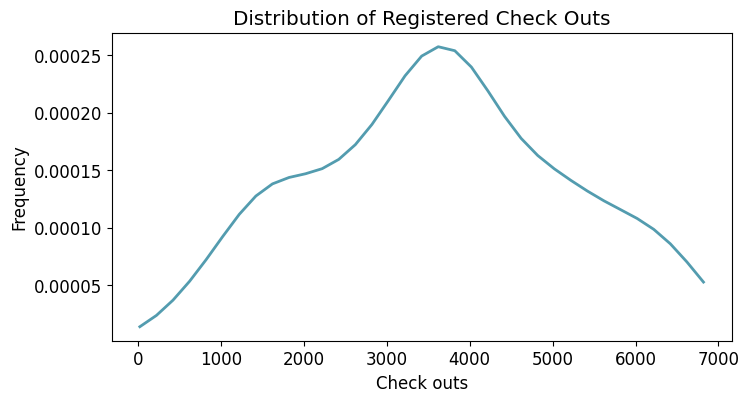

```python
densityplot(x_data = x_data
            , density_est = density_est
            , x_label = 'Check outs'
            , y_label = 'Frequency'
            , title = 'Distribution of Registered Check Outs')
```

```python
type(density_est)
```

```
scipy.stats._kde.gaussian_kde
```

或许我们可以堆叠多个直方图来分析分布～

### 步骤5：组间分析

- 组间定量比较
- 分组粒度
- 组间聚类

#### 柱状图

- 一级类间均值方差比较

定义绘制柱状图的函数

```python
# 分天分析统计特征
mean_total_co_day = daily_data[['weekday', 'cnt']].groupby('weekday').agg(['mean', 'std'])
mean_total_co_day.columns = mean_total_co_day.columns.droplevel() # ['mean', 'std']


def barplot(x_data, y_data, error_data, x_label, y_label, title):
    _, ax = plt.subplots()
    # 柱状图（注：x_data是不能接受str或者float的）
    ax.bar(x_data, y_data, color = '#539caf', align = 'center')
    # 绘制方差
    # ls='none'去掉bar之间的连线
    ax.errorbar(x_data, y_data, yerr = error_data, color = '#297083', ls = 'none', lw = 5) # lw线宽
    ax.set_ylabel(y_label)
    ax.set_xlabel(x_label)
    ax.set_title(title)
```

```python
# mean_total_co_day.columns
daily_data[['weekday', 'cnt']].groupby('weekday').agg(['mean', 'std'])
```

| weekday | cnt mean | cnt std |
| --- | --- | --- |
| 0 | 4228.828571 | 1872.496629 |
| 1 | 4338.123810 | 1793.074013 |
| 2 | 4510.663462 | 1826.911642 |
| 3 | 4548.538462 | 2038.095884 |
| 4 | 4667.259615 | 1939.433317 |
| 5 | 4690.288462 | 1874.624870 |
| 6 | 4550.542857 | 2196.693009 |

绘图函数调用

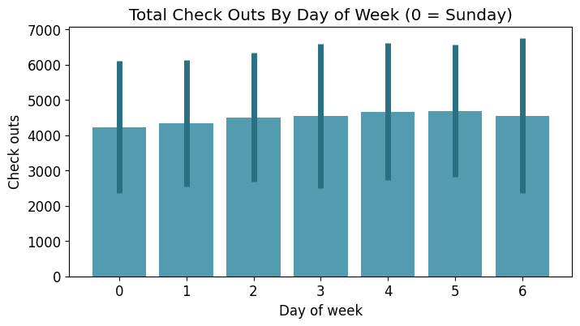

```python
barplot(x_data = mean_total_co_day.index.values
        , y_data = mean_total_co_day['mean']           # 取每天租车量的均值
        , error_data = mean_total_co_day['std']
        , x_label = 'Day of week'
        , y_label = 'Check outs'
        , title = 'Total Check Outs By Day of Week (0 = Sunday)')
```

轻松一刻：

[figure not shown]

#### 堆积柱状图

- 多级类间相对占比比较

```python
mean_by_reg_co_day = daily_data[['weekday', 'registered', 'casual']].groupby('weekday').mean()
mean_by_reg_co_day
```

| weekday | registered | casual |
| --- | --- | --- |
| 0 | 2890.533333 | 1338.295238 |
| 1 | 3663.990476 | 674.133333 |
| 2 | 3954.480769 | 556.182692 |
| 3 | 3997.394231 | 551.144231 |
| 4 | 4076.298077 | 590.961538 |
| 5 | 3938.000000 | 752.288462 |
| 6 | 3085.285714 | 1465.257143 |

分天统计注册和偶然使用的情况

```python
mean_by_reg_co_day = daily_data[['weekday', 'registered', 'casual']].groupby('weekday').mean()
```

分天统计注册和偶然使用的占比

```python
mean_by_reg_co_day['total'] = mean_by_reg_co_day['registered'] + mean_by_reg_co_day['casual']
mean_by_reg_co_day['reg_prop'] = mean_by_reg_co_day['registered'] / mean_by_reg_co_day['total']
mean_by_reg_co_day['casual_prop'] = mean_by_reg_co_day['casual'] / mean_by_reg_co_day['total']
```

定义绘制堆积柱状图的函数

```python
def stackedbarplot(x_data, y_data_list, y_data_names, colors, x_label, y_label, title):
    _, ax = plt.subplots()
    # 循环绘制堆积柱状图
    for i in range(0, len(y_data_list)):
        if i == 0:
            ax.bar(x_data, y_data_list[i], color = colors[i], align = 'center', label = y_data_names[i])
        else:
            # 采用堆积的方式，除了第一个分类，后面的分类都从前一个分类的柱状图接着画
            # 用归一化保证最终累积结果为1，下面bottom参数表示纵向从哪里开始画
            ax.bar(x_data, y_data_list[i], color = colors[i], bottom = y_data_list[i - 1], align = 'center', label = y_data_names[i])
    ax.set_ylabel(y_label)
    ax.set_xlabel(x_label)
    ax.set_title(title)
    ax.legend(loc = 'upper right') # 设定图例位置
```

调用绘图函数

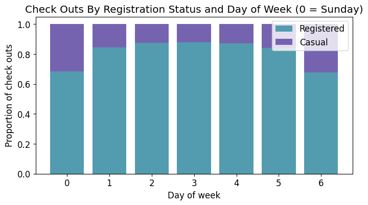

```python
stackedbarplot(x_data = mean_by_reg_co_day.index.values
               , y_data_list = [mean_by_reg_co_day['reg_prop'], mean_by_reg_co_day['casual_prop']]
               , y_data_names = ['Registered', 'Casual']
               , colors = ['#539caf', '#7663b0']
               , x_label = 'Day of week'
               , y_label = 'Proportion of check outs'
               , title = 'Check Outs By Registration Status and Day of Week (0 = Sunday)')
```

- 从这幅图你看出了什么？工作日 VS 节假日（每天预约和偶然租车的相对量）
- 为什么会有这样的差别？周末的随机性更大。

#### 分组柱状图

- 多级类间绝对数值比较

定义绘制分组柱状图的函数

```python
def groupedbarplot(x_data, y_data_list, y_data_names, colors, x_label, y_label, title):
    _, ax = plt.subplots()
    # 设置每一组柱状图的宽度
    total_width = 0.8
    # 设置每一个柱状图的宽度
    ind_width = total_width / len(y_data_list)
    # 计算每一个柱状图的中心偏移
    alteration = np.arange(-total_width/2+ind_width/2, total_width/2+ind_width/2, ind_width)

    # 分别绘制每一个柱状图
    for i in range(0, len(y_data_list)):
        # 横向散开绘制
        ax.bar(x_data + alteration[i], y_data_list[i], color = colors[i], label = y_data_names[i], width = ind_width)
    ax.set_ylabel(y_label)
    ax.set_xlabel(x_label)
    ax.set_title(title)
    ax.legend(loc = 'upper right')
```

调用绘图函数

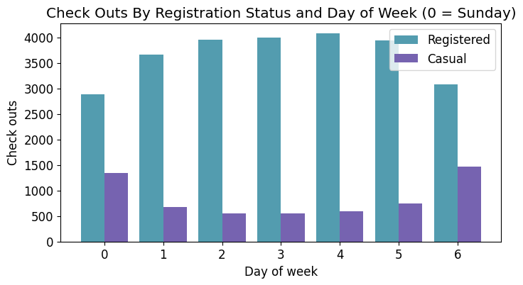

```python
groupedbarplot(x_data = mean_by_reg_co_day.index.values
               , y_data_list = [mean_by_reg_co_day['registered'], mean_by_reg_co_day['casual']]
               , y_data_names = ['Registered', 'Casual']
               , colors = ['#539caf', '#7663b0']
               , x_label = 'Day of week'
               , y_label = 'Check outs'
               , title = 'Check Outs By Registration Status and Day of Week (0 = Sunday)')
```

- 偏移前：ind_width/2
- 偏移后：total_width/2
- 偏移量：total_width/2-ind_width/2

#### 箱式图

- 多级类间数据分布比较
- 柱状图 + 堆叠灰度图

```python
# data.hist()
```

只需要指定分类的依据，就能自动绘制箱式图

```python
days = np.unique(daily_data['weekday']) # [0, 1, 2, 3, 4, 5, 6]
bp_data = []
for day in days:
    bp_data.append(daily_data[daily_data['weekday'] == day]['cnt'].values)
```

```python
# bp_data
```

定义绘图函数

```python
def boxplot(x_data, y_data, base_color, median_color, x_label, y_label, title):
    _, ax = plt.subplots()

    # 设置样式
    ax.boxplot(y_data
               # 箱子是否颜色填充
               , patch_artist = True
               # 中位数线颜色
               , medianprops = {'color': base_color}
               # 箱子颜色设置，color：边框颜色，facecolor：填充颜色
               , boxprops = {'color': base_color, 'facecolor': median_color}
               # 猫须颜色whisker
               , whiskerprops = {'color': median_color}
               # 猫须界限颜色whisker cap
               , capprops = {'color': base_color})

    # 箱图与x_data保持一致
    ax.set_xticklabels(x_data)
    ax.set_ylabel(y_label)
    ax.set_xlabel(x_label)
    ax.set_title(title)
```

调用绘图函数

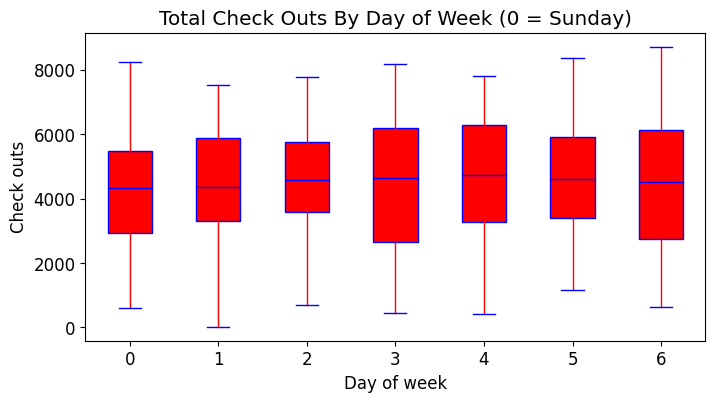

```python
boxplot(x_data = days
        , y_data = bp_data
        , base_color = 'b'
        , median_color = 'r'
        , x_label = 'Day of week'
        , y_label = 'Check outs'
        , title = 'Total Check Outs By Day of Week (0 = Sunday)')
```

```python
# bp_data
# days
```

### 简单总结

- 关联分析、**定量**数值比较：散点图、曲线图
- 分布分析（**定量**数据：粗处度／细处度）：灰度图、密度图
- 涉及分类的分析（关于**定序**／**定类**数据）：柱状图、箱式图

## 课程学习已完成

> 1 min

恭喜，你已经完成了本实验的全部学习任务